# Into the Tidyverse

Session Two Solutions

As always, we start by loading the tidyverse package.

```r
library(tidyverse)
```

## Coding Basics

### R as a Calculator 1

#### Part 1

```r
# notice that we don't have to use `to =` and `from = `
# since these parameters can be recognised by postiion
integers <- seq(0, 100)
```

#### Part 2

```r
squares <- integers ^ 2
```

#### Part 3

```r
squares_df <- tibble(integers, squares)
```

Let’s have a look at the first four rows of `squares_df` just to make sure that everything is as expected.

```r
head(squares_df, n = 4)
```

| integers | squares |
| --- | --- |
| 0 | 0 |
| 1 | 1 |
| 2 | 4 |
| 3 | 9 |

#### Part 4

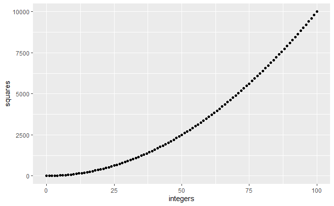

```r
# no need to specify `data =` or `mapping =`
ggplot(squares_df) +
  geom_point(aes(x = integers, y = squares))
```

### R as a calculator

#### Part 1

```r
x <- seq(-6, 6, length.out = 1000)
```

NB: Another interesting parameter of `seq` is `by =` which determines what gap should be between each value in the sequence.

#### Part 2

```r
# note - R uses radians!
y <- sin(x)
```

#### Part 3

```r
# you can call this whatever you want
sin_df <- tibble(x, y)
```

#### Part 4

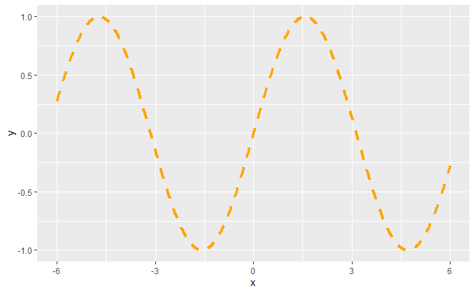

```r
ggplot(sin_df) +
  geom_line(aes(x = x, y = y), col = 'orange', linetype = 2, size = 1.5)
```

### Specifying Parameters by Position

#### Part 1

`data` and `mapping` are perhaps the most obvious ones but it turns out that you can actually remove `x =` and `y =` too (though in my personal opinion, it is unclear to do so). `colour =` must be specified though.

## Reading CSVs

Remember to set your working directory first with `Session > Set Working Directory...` in the top bar of RStudio

### The ‘People’ Dataset

#### Part 1

```r
people <- read_csv('data/people.csv',
                   col_types = cols(
                     sex = col_factor(),
                     race = col_factor(),
                     earn = col_integer(),
                     age = col_integer()
                   ))
```

#### Part 2

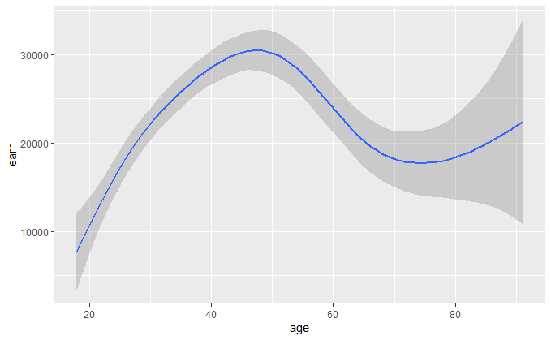

```r
ggplot(people) +
  geom_smooth(aes(x = age, y = earn))
```

#### Part 3

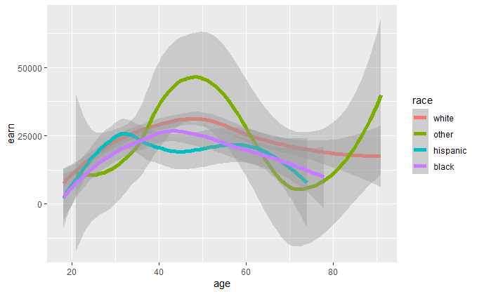

```r
ggplot(people) +
  geom_smooth(aes(x = age, y = earn, col = race), size = 2)
```

NB: Here error bars are useful. It appears from the smoothed curve alone that being a race other than white, black, or Hispanic may relate to having large earnings later in life. This pattern is most likely due to a single outlier. We can spot this because the errors on the `other` curve are very large for high age, signifying uncertainly in the curve’s position.

### Datasets from the Web

#### Part 1

I hope that this presents no difficulties.

#### Part 2

I will save this in my data folder as `movies.csv`.

#### Part 3

```r
# this dataset is fairly clean so we can import it straight in
movies <- read_csv('data/movies.csv')
```

#### Part 4

```r
movies <- movies %>%
  mutate(Genre = ifelse(Genre %in% c('Comdy', 'comedy'), 'Comedy', Genre)) %>%
  mutate(Genre = ifelse(Genre %in% c('Romence', 'romance'), 'Romance', Genre)) %>%
  mutate(`Worldwide Gross` = as.double(str_replace(`Worldwide Gross`, '\\$', '')))
```

#### Part 5

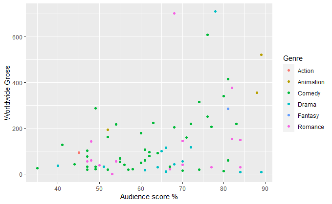

```r
ggplot(movies) +
  geom_point(aes(x = `Audience score %`, y = `Worldwide Gross`, col = Genre))
```

## Line Geometries

### Smoothing Methods

#### Part 1

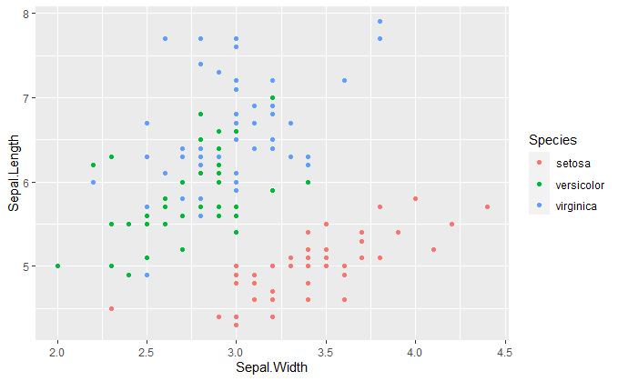

```r
ggplot(iris) +
  geom_point(aes(x = Sepal.Width, y = Sepal.Length, col = Species))
```

#### Part 2

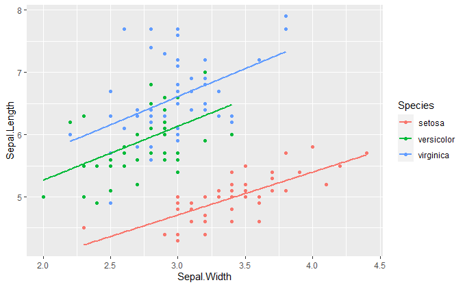

```r
ggplot(iris, aes(x = Sepal.Width, y = Sepal.Length, col = Species)) +
  geom_point() +
  geom_smooth(se = FALSE, method = 'lm')
```

#### Part 3

We’ll look at LOESS since GAMs are generally more applicable to larger datasets

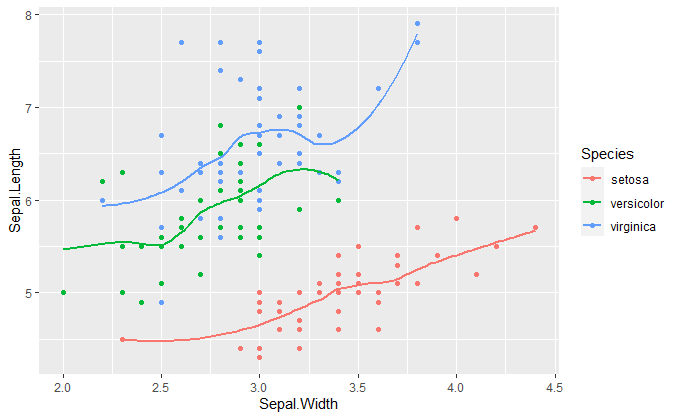

```r
ggplot(iris, aes(x = Sepal.Width, y = Sepal.Length, col = Species)) +
  geom_point() +
  geom_smooth(se = FALSE, method = 'loess')
```

#### Part 4

The default for small datasets is LOESS and for large it is GAMs. This dataset is small so `geom_smooth` uses LOESS.

## Going Beyond

### Theming Graphs

#### Part 1

I will make a plot of highway mileage vs city mileage

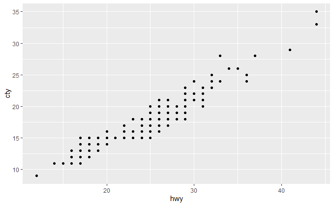

```r
ggplot(mpg) +
  geom_point(aes(x = hwy, y = cty))
```

#### Part 2

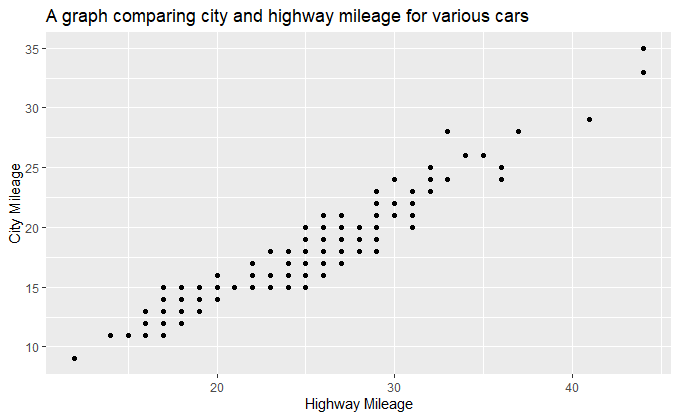

```r
ggplot(mpg) +
  geom_point(aes(x = hwy, y = cty)) +
  labs(x = 'Highway Mileage',
       y = 'City Mileage',
       title = 'A graph comparing city and highway mileage for various cars')
```

#### Part 3

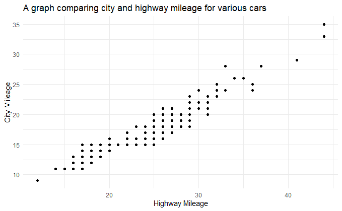

```r
ggplot(mpg) +
  geom_point(aes(x = hwy, y = cty)) +
  labs(x = 'Highway Mileage',
       y = 'City Mileage',
       title = 'A graph comparing city and highway mileage for various cars') +
  theme_minimal()
```

#### Part 4

Another theme I like is `theme_bw()` which is an understated black and white design.

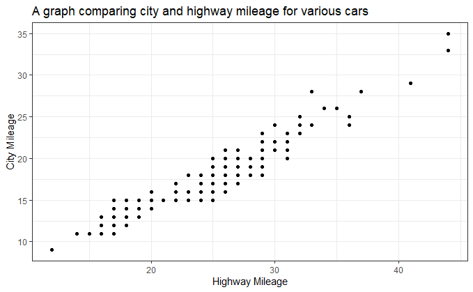

```r
ggplot(mpg) +
  geom_point(aes(x = hwy, y = cty)) +
  labs(x = 'Highway Mileage',
       y = 'City Mileage',
       title = 'A graph comparing city and highway mileage for various cars') +
  theme_bw()
```

### ggplot Objects

#### Part 1

Done.

#### Part 2

This has saved the plot we created to the object `p`. Typing `p` will now generate the plot.

#### Part 3

Done.

#### Part 4

This has created the plot we had before with an additional smoothing layer.

### Scripting

I will leave this for you to look at yourself.